# A3 - Data Visualization (Incarceration)

Tyler Takeuchi

5/22/22

## Introduction

The problem domain I am choosing to analyze is the proportion of black people in jail compared to the proportion of black people within a particular location. A commonly heard rhetoric about racial injustice revolves around the disproportiante incarceration of black people in the US. I believe that this rhetoric can be supported by comparing the racial demographics of an area, then comparing that to the distribution of racial demographics in jails. Additionally, I will be taking a closer look at the proportion of black incarcertaion in rural areas to gain context on racial injustice in lesser diverse areas. The variables I will be focusing on are black_pop_15to64, total_pop_15to64, total_jail_pop, and black_jail_pop.

## Summary Information

A quick glance at some of the values calculated from the dataset is concerning. One value I wanted to look at specifically was the black jail proportion in comparison to the proportion of black people as a whole. The black population represented 13.4 percent of the US population in 2018, however, black people represented over 33.5 percent of the population in jails. This disparity must be tied to causal systemic factors and is virtualy irrefutable. Though there are missing values, rural areas seemed to have less racial disparities with incarcertion. This does not suggest that there is no injustice but the disparity was slightly less, the black population made up about 9 percent of rural populations, and represented 24 percent of the jailed populations. With 56599 missing values in the black_jail_pop variable, there was still 247547 incarcerted black people for 2018. Outside sources (BJS) suggested that there were over 475000 black people in jail in 2017.

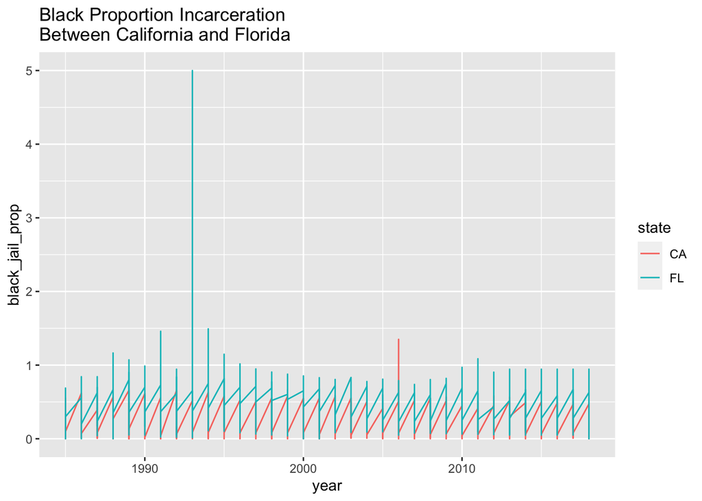

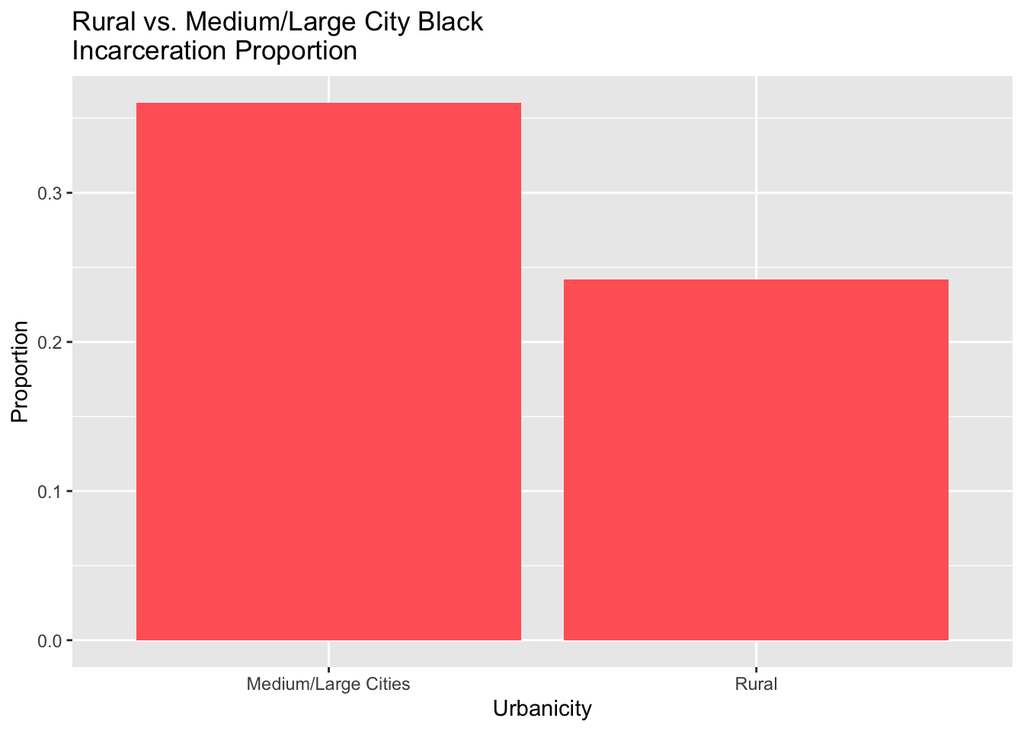

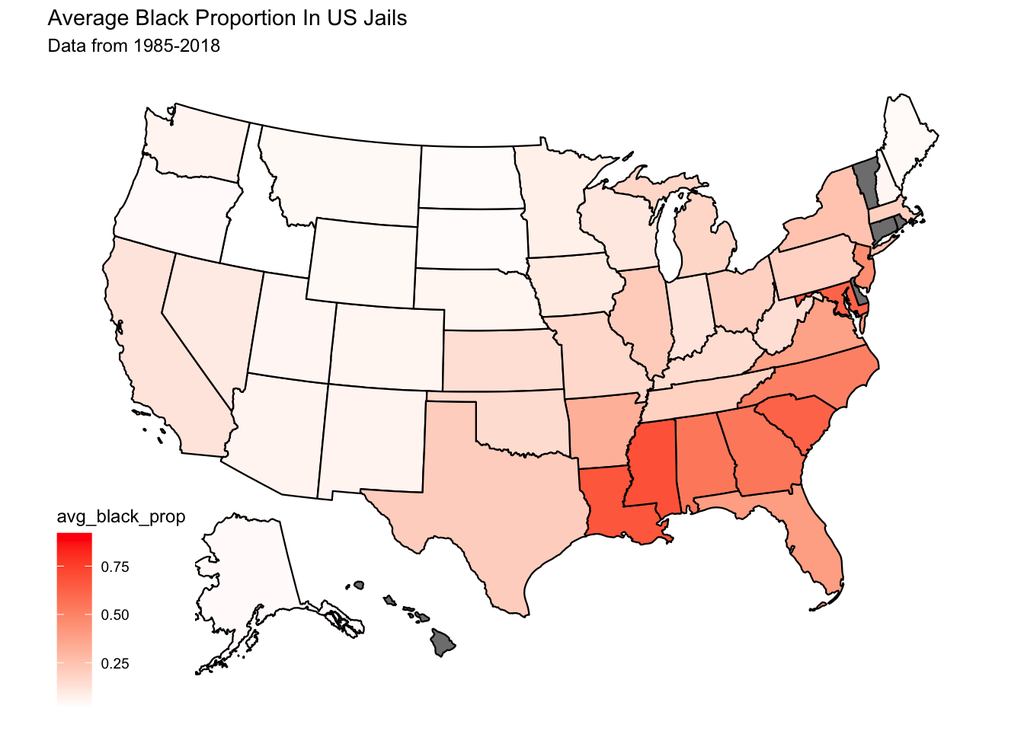